# HW1 Problem 7 (BDA Chap3 problem 3.5)

**Suppose that we weigh an object five times and measure weights, rounded to the nearest pound, of $10, 10, 12, 11, 9$. Assume the unrounded measurements are normally distributed with a noninformative prior distribution on the mean $\mu$ and variance $\sigma^2$.**

*python script: hw1prob7.py*

## 7-(a)(b)

**Give the posterior distribution for $(\mu ,\sigma^2)$ obtained by pretending that the observations are exact unrounded measurements. Give the correct posterior distribution for $(\mu, \sigma^2)$ treating the measurement as rounded.**

When assuming exact unrounded measurements,

$$y_i \sim N(\mu, \sigma^2)$$

and with a noninformative prior $\propto 1/\sigma^2$

$$f(\mu, \sigma^2|y_1,...,y_5) = f(\mu|\sigma^2,y_1,...,y_5)f(\sigma^2|y_1,...,y_5)$$

where

- $\mu|\sigma^2,y_1,...,y_5 \sim N(\bar{y}, \sigma^2/5)$
- $\sigma^2|y_1,...,y_5 \sim inv.gamma(2, S^2/2) = inv.chisq(4, S^2/4)$

On the other hand, if assuming the rounded situation, $$y_{i, true} \sim truncated-normal(\mu, \sigma^2)$$ on $[y_i - 0.5, y_i + 0.5]$

and with a noninformative prior $\propto 1/\sigma^2$

$$f(\mu, \sigma^2|y_1,...,y_5) \propto \sigma^{-2} \prod_{i=1}^5 (\Phi(\frac{y_i + 0.5 - \mu}{\sigma}) - \Phi(\frac{y_i - 0.5 - \mu}{\sigma}))$$

## 7-(c)

**How do the incorrect and correct posterior distributions differ?** **Compare means, variances, and contour plots.**

Using the results from (a) and (b), let's draw samples to compare means and variances. Since the direction of this problem requires to draw contour plots, I will use grid approximations for two posteriors and draw samples from the grids.

Note that, I used a 3rd-party package 'scipy' to get inverse-gamma density values and normal cumulative distribution values. (I think it is much better to use R for this problem... Actually, the procedure plotting a contour plot using matplotlib is not that much neat, either.)

```
obs_mean: 10.4
obs_sample_var: 1.3
==Posterior Comparison==
            (mu_mean, mu_var), (sigma2_mean, sigma2_var)
as   exact: ((10.4, 0.27858), (1.39317, 0.43636))
as rounded: ((10.40074, 0.27667), (1.30215, 0.4584))
```

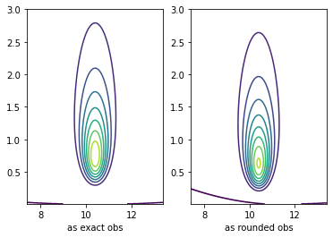

```python
import numpy as np
import scipy.stats
import matplotlib.pyplot as plt


observations = np.array([10, 10, 12, 11, 9])
obs_mean = np.mean(observations)
obs_S2 = sum([(y-obs_mean)**2 for y in observations])
print("obs_mean:", obs_mean,"\nobs_sample_var:", obs_S2/4) #10.4, 1.3

# grid_x = np.linspace(9, 12, 1000)
grid_x = np.linspace(obs_mean-3, obs_mean+3, 1000)
grid_y = np.linspace(0.01, 3, 1000)
meshgrid_x, meshgrid_y = np.meshgrid(grid_x, grid_y)

def generate_contour_level_matrix_as_true(mu_meshgrid, sigma2_meshgrid):
    term1 = scipy.stats.norm.logpdf(mu_meshgrid, loc=obs_mean, scale=np.sqrt(sigma2_meshgrid/5))
    term2 = scipy.stats.invgamma.logpdf(sigma2_meshgrid, a=2, scale=obs_S2/2)
    # def scipy.stats.invgamma: scaled after inversion from gamma distribution
    # scipy invgamma ref: https://docs.scipy.org/doc/scipy/reference/generated/scipy.stats.invgamma.html#scipy.stats.invgamma
    return np.exp(term1+term2)/np.sum(np.exp(term1+term2))

value_mesh_as_true = generate_contour_level_matrix_as_true(meshgrid_x, meshgrid_y)


def generate_contour_level_matrix_as_rounded(mu_meshgrid, sigma2_meshgrid):
    z_mesh = np.ones(mu_meshgrid.shape)
    for obs in observations:
        term1 = scipy.stats.norm.cdf(obs, loc=mu_meshgrid-0.5, scale=np.sqrt(sigma2_meshgrid))
        term2 = scipy.stats.norm.cdf(obs, loc=mu_meshgrid+0.5, scale=np.sqrt(sigma2_meshgrid))
        z_mesh *= (term1 - term2)
    z_mesh = z_mesh/sigma2_meshgrid
    return z_mesh/np.sum(z_mesh)

value_mesh_as_rounded = generate_contour_level_matrix_as_rounded(meshgrid_x, meshgrid_y)


def summary_from_meshgrid(meshgrid_x, meshgrid_y, meshgrid_val, print_round=5):
    margianl_x_prob = np.sum(meshgrid_val, axis=0)
    margianl_x_prob = margianl_x_prob/np.sum(margianl_x_prob)
    x_mean = np.sum(meshgrid_x[0,:] * margianl_x_prob)
    x2_mean = np.sum((meshgrid_x[0,:]**2) * margianl_x_prob)
    x_var = x2_mean - x_mean**2

    marginal_y_prob = np.sum(meshgrid_val, axis=1)
    marginal_y_prob = marginal_y_prob/np.sum(marginal_y_prob)
    y_mean = np.sum(meshgrid_y[:,0] * marginal_y_prob)
    y2_mean = np.sum((meshgrid_y[:,0]**2) * marginal_y_prob)
    y_var = y2_mean - y_mean**2
    return (round(x_mean, print_round), round(x_var, print_round)), (round(y_mean, print_round), round(y_var, print_round))


# part of (c)
## pairs of mean and variance
print("==Posterior Comparison==")
print("            (mu_mean, mu_var), (sigma2_mean, sigma2_var)")
print("as   exact:", summary_from_meshgrid(meshgrid_x, meshgrid_y, value_mesh_as_true))
print("as rounded:", summary_from_meshgrid(meshgrid_x, meshgrid_y, value_mesh_as_rounded))

## contour plots
ax1 = plt.subplot(121)
plt.contour(meshgrid_x, meshgrid_y, value_mesh_as_true, levels=10)
plt.xlabel("as exact obs")
ax2 = plt.subplot(122, sharex=ax1)
plt.contour(meshgrid_x, meshgrid_y, value_mesh_as_rounded, levels=10)
plt.xlabel("as rounded obs")
plt.show()
```

Outputs show the posterior means, variances and contour plots for two assumptions, respectively. I also have attatched (naive) mean and variance from observations, too.

Roughly speaking, there is no big difference between the cases under two different assumptions, as exact and as rounded. $\mu$ values are so close each other. $\sigma^2$ are slightly differ, but the gap is not large.

Since we used noninformative prior, it is possible to compare the posterior moments with (naive) sample moments. (It may be fair to note that these naive sample moments can be justified by using many frequentist' properties.) Interestingly, the $\sigma^2$ value under the assumption 'as rounded' is closer to sample variance from the observations than the $\sigma^2$ value from the case taking the observations as exact.

So we cannot say that 'modeling as rounded value' is useless at all. In the same time, however, I want to say that it requires more tiring procedure like dealing with trunctated normal, which make hard to enjoy a conjugacy, so perhaps the cost is bigger than what we get from that complexity (except for a situation that the accuracy is extremly important.)

## 7-(d)

**Let $z=(z_1,...,z_5)$ be the original, unrounded measurements corresponding to the five observations above.** **Draw simulations from the posterior distribution of $z$.** **Compute the posterior mean of $(z_1-z_2)^2$.**

Under the assumption that observations are rounded, we already have a data-generating model(likelihood), i.e. $$z_i = y_{i, true} \sim truncated-normal(\mu, \sigma^2)$$ on $[y_i - 0.5, y_i + 0.5]$ for each $i=1,2,3,4,5$.

Using the grid approximation result from (c), we can draw posterior samples of $(\mu, \sigma^2)$. So, to draw samples of $z$, we can repeat

1. draw $(\mu, \sigma^2)$ from the grid.
2. draw $z_1,...,z_5$ under the trunctated normal model at the drawn value from 1.

After drawing 10,000 samples for z, I will calculate $(z_1-z_2)^2$ on those 10,000 realizations. By the law of large numbers, it is an approximation of the posterior mean of $(z_1-z_2)^2$.

For (my) convenience, I used 'scipy' again for a truncated normal sampler. (even if it does not seem too much hard to implement if we can use a normal cdf function.)

```python
# part of (d)
## grid sampling
vectorized_mesh_x = np.reshape(meshgrid_x, (meshgrid_x.size,1))
vectorized_mesh_y = np.reshape(meshgrid_y, (meshgrid_y.size,1))
vectorized_mesh_as_rounded = np.reshape(value_mesh_as_rounded, value_mesh_as_rounded.size)
rng = np.random.default_rng()
posterior_samples_idx = rng.choice(np.arange(vectorized_mesh_as_rounded.size), size=10000, p=vectorized_mesh_as_rounded)

## (z1, z2) posterior predictive sampling
z1_vec = []
z2_vec = []
for idx in posterior_samples_idx:
    # scipy truncated normal ref: https://docs.scipy.org/doc/scipy/reference/generated/scipy.stats.truncnorm.html#scipy.stats.truncnorm
    loc_param = vectorized_mesh_x[idx]
    scale_param = np.sqrt(vectorized_mesh_y[idx])
    arg_a = (observations[0] - 0.5 - loc_param) / scale_param
    arg_b = (observations[0] + 0.5 - loc_param) / scale_param
    z1_vec.append(scipy.stats.truncnorm.rvs(a=arg_a, b=arg_b, loc=loc_param, scale=scale_param))
    #note that y1=y2=10, so we can share arg_a and arg_b
    z2_vec.append(scipy.stats.truncnorm.rvs(a=arg_a, b=arg_b, loc=loc_param, scale=scale_param))

print("approximated mean of (z1-z2)^2:", np.mean([(z1-z2)**2 for z1, z2 in zip(z1_vec, z2_vec)]))
```

```
approximated mean of (z1-z2)^2: 0.15671006362585707
```

The approximated mean of square of difference between $z_1$ and $z_2$ is about 0.1567. It is natural to be close to 0, cause $y_1=y_2=10$. Heuristically we can say that this value only reflects the variance of the same predictive distribution at $y_{obs}=10$, since it is a kind of MSE.